# 这

Rush week is just the first dehumanizing experience for poor little MIT first-year students. I remembered orientation week at Hop kins. I knew who my roommate would be and where my room would be. Driving up to Baltimore from Potomac, with the '68 Mercury Park Lane stuffed full of my stereo equipment and bicycle and clothes, I was still terrified. There wasn't room for my parents, so they took the train and I met them there. I think I would have been more terrified if I were a dormless person from the beginning, as they are at MIT.

在霍普金斯大学，这是一所规模小得多的本科学校，所以他们可以更轻松地管理这些事情，而且一些校友内心有足够温暖的感情，可以给它捐赠，这样他们就不必总是苦苦寻找金钱和削减预算。 -在霍普金斯大学，我最快乐的迎新记忆是与我的新生迎新小组和导师杰里·科洪（宾夕法尼亚大学学士；麻省理工学院博士）坐在阳光普照的草地上，谈论环境工程以及如何拯救世界。迎新周是一个培养人的一周，是一个结识新朋友、交朋友、邀请他们到我宿舍喝茶的机会。

At Hopkins-OK, it's a much smaller undergraduate school so they can manage these things more easily, and some alumni have warm enough feelings in their hearts to give it an endowment so they don't always have to be grubbing for money and cutting budgets-at Hopkins my happiest memory of orientation was sitting on the sun-drenched grass with my freshman orientation group and my adviser, Jerry Cohon (B.S., Penn; Ph.D., MIT) and talking about environmental engineering and how to save the world. Orientation week was a nurturing week, an opportunity to meet people, make friends, invite them over to my dorm room for tea.

麻省理工学院则不然。Boom，你这个哭哭啼啼的小书呆子，可能一生中从未出去约会过，欢迎你在生活安排中做出最后的选择。欢迎加入兄弟会兄弟，拍拍你的背，并在地下代码中贴上一张贴纸，上面写着“这家伙是个失败者”。欢迎被熟人抛弃，他们承诺当你去洗手间时他们会等你。欢迎来到地狱。

Not so at MIT. Boom, you sniveling little nerd, who probably never went out on a date in your life, welcome to getting your last choice in living arrangements. Welcome to fraternity brothers patting you on the back and putting a sticker there that says, "This guy's a loser" in the underground code. Welcome to being abandoned by acquaintances who promise they'll wait when you go to the bathroom. Welcome to hell.

霍华德·格尔曼 (Howard Gelman) 是第一个前来品尝香草冰淇淋和新鲜蓝莓的人，这些冰淇淋和新鲜蓝莓装在玻璃盘上，配上多尔西餐具套装中的镀银勺子。霍华德是一位来自纽约的矮胖新生。他的声音很爱发牢骚，想主修第六课。高科技。双E.电气工程和计算机科学；缩写发音为“EEKS”。

Howard Gelman was the first to arrive for vanilla ice cream and fresh blueberries served on glass plates with silver plated spoons from the Dorseys' flatware set. Howard was a short, fat freshman from New York. He had a whiny voice and wanted to major in Course Six. High tech. Double E. Electrical Engineering and Computer Science; pronounced "EEKS" in short form.

是时候开始赚取免费食宿了。

It was time to start earning my free room and board.

“所以，”我说。“你最近怎么样？”

"So," I said. "How are things going for you?"

“嗯。嗯。他们可以做得更好。我在这儿，不是吗？”

"Ummmm. Ummmm. They could be better. I'm here, aren't I?"

你怎么和这样的人说话？“所以，”我说。暂停。“你在哪里上高中？”

How do you talk to somebody like this? "So," I said. Pause. "Where'd you go to high school?"

“科学，”他指的是布朗克斯科学学院。如果他是一位才华横溢的音乐家或演员，这将是茱莉亚音乐学院，而他的答案将是表演艺术学院。但他的数学很好，比曼哈顿最好的人还要好，而且这里是麻省理工学院。

"Science," he said, referring to the Bronx School of Science. If he were a talented musician or actor this would be Juilliard and his answer would have been the School for Performing Arts. But he was good in math, better than the best in Manhattan, and this was MIT.

“你住哪个房间？” 我问。

"What room are you staying in?" I asked.

“303.这只是一个临时任务。我真的很想去麦格雷戈，但他们已经满了。我要看看下学期我是否可以转学到那里。”

"303. It's just a temporary assignment. I really wanted to be in MacGregor but they were full. I'm going to see whether I can transfer there next term."

祝你好运。一旦他们看到了自己的观点，房间就只有一种打开方式，我怀疑你会想要这种方式。

Good luck. Once they see their views there's only one way a room is going to open up, and I doubt you'd want to get it that way.

我想知道什么时候会有其他人出现。这也太尴尬了。“好吧，其他人随时都会到，”我说。

When is someone else going to show up, I wondered. This is too awkward. "Well, the rest of the people should be here any minute," I said.

“这是泊松分布，人们如何到达任何队列，”他说。“如果从现在到 7 点 10 分之间有 8 个人到达，那么在 15 分钟内总共有 9 个人，或者说每 9 分钟内每 15 个人到达这里一次。在 7 点 05 分之前再有两个人到达这里的概率是 e 的负六。六的立方除以三的阶乘。你有计算器吗？”

"It's a Poisson distribution, how people arrive at any queue," he said. "If eight people will arrive between now and 7:10, that will make nine total in fifteen minutes, or once per every fifteen over nine minutes. The probability that two more people will arrive here by 7:05 is e to the minus six times six cubed over three factorial. Do you have a calculator?"

这孩子不错啊 让我们让他接受训练并离开这里，做一些富有成效的事情，比如弄清楚如何在欧洲部署军队或解码苏联的电缆传输。

This kid's good. Let's get him trained and out of here, doing something productive like figuring out how to deploy troops in Europe or decoding Soviet cable transmissions.

“不，我更喜欢在脑子里做那些简单的事情，”我说。

"No, I prefer to do the easy ones in my head," I said.

一位身穿黑色衬衫、印有红色字母 Sigma Delta 的女士走了进来。“嗨，”她说。“我是辛迪·布鲁克斯。我住在隔壁。”

A woman who wore a black shirt with the red letters sigma delta walked in. "Hi," she said. "I'm Cindy Brooks. I live next door."

布鲁克斯。这个名字听起来很熟悉。哦，是的，布鲁克斯教授这学期正在教我的高级控制课程。

Brooks. That name sounds familiar. Oh yeah, Professor Brooks is teaching my advanced controls class this semester.

“你和教授有关系吗？”

"Are you any relation to the professor?"

“我是他的女儿。”

"I'm his daughter."

法学院的金菲尔德教授也有一个女儿。但这个故事已经写好了。

Professor Kingfield at the law school had a daughter, too. But that story's already been written.

“比如说，我喜欢你的球衣，”我说，指的是上面有红色字母的黑色足球球衣。“西格玛德尔塔代表什么？”

"Say, I like your shirt," I said, referring to the black football jersey with red letters on it. "What does sigma delta stand for?"

“运动死亡。Sigma Delta 是高级学院联谊会。实际上，我们正在寻找愿意成为一些承诺的小兄弟的人。”

"Sport Death. Sigma Delta is the Senior House sorority. Actually we're looking for guys who want to be little brothers for some of the pledges."

“这涉及什么？”

"What does that involve?"

“好吧，每个人生来就有 100 点纯洁点，或者说他们没有做过的事情，”她说。“我们的入会者必须填写表格，这就是他们获得入职前分数的方式。为了获得录取，他们必须将分数降低10%。入职后分数就是衬衫背面的数字。作为弟弟你会帮助他们实现这一点。名单在 35 号楼的计算机系统上。”

"Well, everyone is born with 100 purity points, or things they haven't done," she said. "Our pledges have to fill out the form, and that's how they get their preinitiation score. To get admitted, they have to reduce their score by 10 percent. The postinitiation score is the number on the back of the shirt. As a little brother you would help them accomplish that. The list is on the computer system in Building 35."

一切都可以量化。

Everything can be quantified.

“嗯，我想我教堂里的朋友不会同意。也许你应该在这里和霍华德谈谈。”

"Well, I don't think my friends at church would approve. Maybe you ought to talk to Howard here."

另外两个人走了进来，从冰箱里拿出了冰淇淋。一名来自加纳；另一名来自加纳。另一个是来自波兰的数学专业大二学生。黛安娜，前一天向她的客户口述这封信的女士走了进来。

Two others came in and took their ice cream out of the freezer. One was from Ghana; the other was a sophomore math major from Poland. Dianne, the woman dictating the letter to her client the day before, walked in.

“那么这里到底是怎么回事？” 她问。“你是不是想一层一层地巴结我们，免得我们组织起来把你赶出去，然后民主选导师？你是在玩什么‘分而治之’的游戏吗？” 她微笑着，好像她不是故意的，只是在考验我，看看她是否能把口头服务高手打过我。

"So what's the deal here?" she asked. "Are you trying to butter us up floor by floor so we won't organize to get you kicked out and then select a tutor democratically? Are you playing some 'divide and conquer' game?" She was smiling, as if she didn't mean it, but was just testing me, seeing whether she could put a verbal service ace past me.

“说吧，你认为谁会赢得今年的世界大赛？” 我问。这在大多数圈子里都是有效的。在大多数圈子里，没有人注意到这是一种规避策略。

"Say, who do you think is going to win the World Series this year?" I asked. That works in most circles; in most circles no one even notices it's an evasive maneuver.

“不不不不不。你不会这么容易就脱身的。”她猛然回应道。

"No no no no no. You're not getting off that easy," she volleyed back.

“那么，如果你遇到我的情况，你会怎么做？”

"Well, what would you do in my situation?"

“不能用问题来回答问题。我先问的，”她说。

"No answering a question with a question. I asked first," she said.

其他六名学生吃着冰淇淋，半听着波兰数学学生说一切都是数学，所有的工程都只是美化的技术工作，半听着门边的口头交流。

The other six students ate their ice cream, half-listening to the Polish mathematics student say that everything is mathematics and all engineering is just glorified technician work, half-listening to the verbal exchange near the door.

“好吧，是的，”我说。

"OK, Yes," I said.

“是，什么？”

"Yes what?"

“是的，就像这场骗局获胜方的其他人一样，我是一个贪图金钱的无赖，通过润滑自己进入了这个位置。你想对此做什么？”

"Yes, like everyone else on the winning side of this con game, I'm a money-grubbing sleazeball who greased my way into this position. What do you want to do about it?"

“哦，没什么。我只是好奇。你说，那是一辆意大利赛车吗？也许我们什么时候可以去骑一下。”

"Oh, nothing. I was just curious. Say, is that an Italian racing bike you've got there? Maybe we can go riding sometime."

9 月 15 日

September 15

电话响了; 那是我的母亲。

The phone rang; it was my mother.

“Pepper，你父亲又住院了。他们不知道是心脏病还是癌症还是什么。他发烧了，正在服用各种药物。他们不知道他这次是否能活下来。” ，也许你应该归结为——”

"Pepper, your father's in the hospital again. They don't know whether it's a heart attack or cancer or what. He's got a fever and he's on all kinds of medication. They don't know whether he's going to make it this time, and maybe you should come down to-"

“我会乘坐下一班飞机。”

"I'll be on the next plane."

我和他单独呆在病房里，看着父亲。他已经睡着了，病号服下面裸露的胸部贴着电极。高烧还没有离开他。床边有一台蓝屏示波器，监测着他的生命体征。这就像我在麻省理工学院牢房里的示波器。

Alone with him in the hospital room, I looked at my father. He was asleep, with electrodes taped to his bare chest underneath the hospital gown; the fever hadn't left him. Next to the bed there was an oscilloscope with a blue screen, monitoring his vital signs. It was like the oscilloscope in my cell at MIT.

我想知道护士和医生是否以我看待快速压缩机的方式看待他，作为一种具有输入和输出的设备，在图表上生成点，需要分析、讨论、推理、争论的点。也许他们确实这么想，这样他们就可以与那些没有成功的人保持距离。

I wondered whether the nurses and doctors looked at him the same way I looked at the rapid compression machine, as a device with inputs and outputs, generating points on a graph, points to be analyzed, discussed, reasoned through, argued about. Maybe they did think that way so they could distance themselves from the ones that didn't make it.

现在请不要让他死。请。让我们再陪他几年，也许足以见到他的孙子们了。

Please don't let him die now. Please. Let us have him for a few more years, maybe long enough to see his grandchildren.

护士进来给他量体温。

The nurse came in to take his temperature.

“这很奇怪，”她说。“过去半个小时下降了一度。也许他正在转危为安，变得更好。”

"That's odd," she said. "It went down a degree in the last half hour. Maybe he's turning the corner and getting better."

这可能只是一个巧合。

It was probably just a coincidence.

或者是吗？

Or was it?

# 章节

# C H A P T E R

# 12

# 12

# 两点七十分

# Two Seventy

足够多的卡洛里克人仍然留在学院，可以再次组建一支C联赛足球队，尽管许多人已经向外晋升，担任好学校的教授或在工业界从事高薪工作。不过，卡洛斯还在这里，戴夫·奥尔洛夫斯基也在这里。

Enough of the Calorics were still at the institute to field a C-league soccer team again, although many had moved outward and upward to professorships at good schools or high-paying jobs in industry. Carlos was still here, though, and Dave Orlowski, too.

下半场末段与TEP的比赛比分是0-0。我像往常一样在左翼，卡洛斯在右边，戴夫在中间。

The score in the game with TEP was 0-0 late in the second half. I was at left wing as usual, Carlos at right, Dave at center.

左中卫罗宾将球传给了我；我一触即触到了卡洛斯。他向守门员射门，但戴夫挡住了球，我们以教科书式的方式获胜。

Robin, the left halfback, passed up to me; I one-touched it to Carlos. He shot toward the goalie but Dave deflected it and we won in textbook style.

10 月 19 日

October 19

威尔逊教授在设计课上讲道，“我们将次优化定义为优雅地解决了错误的问题。重新布置正在下沉的泰坦尼克号上的躺椅就是一个例子。” 说到沉船，我想知道威尔逊在我们大约一年前推出的踏板动力船员外壳方面取得了怎样的进展。

We define suboptimization," Professor Wilson lectured the design class, as elegantly solving the wrong problem. Rearranging the deck chairs on the sinking Titanic is an example." Speaking of sinking ships, I wondered how Wilson had progressed with the pedal-powered crew shell we'd launched almost a year before.

第二门课程七十，设计概论，在我的必修本科课程清单上。这是我和我的硕士学位之间最可怕、最大的障碍，因为有二七十人参加了比赛。工程师和设计师每天都在竞争，以最低的成本制造出最好的产品。还有什么比直接参加建造执行指定任务的最佳设备的竞赛更好的方式来完善您的工程教育呢？

Course Two Seventy, Introduction to Design, was on my list of required undergraduate courses. It was the scariest, biggest hurdle between me and my master's degree because two seventy had The Contest. Engineers and designers compete every working day of their lives to make the best product at the lowest cost. What better way to round out your engineering education than to compete directly, in a contest to build the best device to perform a stated task?

威尔逊继续说道：“现在我想稍微改变一下话题，谈谈比赛。今年的比赛将与往年有所不同。而不是像弗劳尔斯教授那样给你们提供同样的材料。已经完成了，今年你必须从“商店”购买东西，我们会给你 12,500 美元的“预算”。此外，你还必须投入一些微电子学。其中一位助教，奈杰尔亚当斯 (Adams) 认为，任何机械工程师都应该在没有连接好至少一个集成电路的情况下离开麻省理工学院。今年比赛的重点是举起最大的重量上山，如果你的电子产品你将获得 500 克的额外重量有效。此外，今年我们将在 11 月的第三周进行初步淘汰赛，您可以在其中多次测试您的设备。比赛将于感恩节前的周一晚上举行。”

Wilson continued, "Now I'd like to change the subject a bit and talk about The Contest. This year The Contest will be a little different from those of years past. Instead of giving you all the same bag of materials, as Professor Flowers has done, this year you'll have to buy things from a 'store,' and we'll give you a 'budget' of $12,500. Also, you'll have to put in some microelectronics. One of the teaching assistants, Nigel Adams, thinks that no mechanical engineer should leave MIT without having wired up at least one integrated circuit. The point of this year's contest is to lift the most weight up a hill, and you'll receive a 500-gram bonus weight if your electronics works. Furthermore, this year we'll have preliminary elimination rounds during the third week in November, in which you'll be able to test your device several times. The Contest itself will be on Monday night before Thanksgiving."

我想，我真的应该读一些讲义。我所知道的是，一些重量必须在二十秒内到达坡道的顶部，并且只需要一个小小的电动机和两个小小的弹簧，以及“商店”中可用的任何其他东西。所有组件都必须安装在大约与面包盒一样大的几何空间内，并且在 12,500 美元的财务空间内。

I really should read some of those handouts, I thought. All I knew was that some weight had to go to the top of a ramp in twenty seconds, and with just a little tiny electric motor and two little tiny springs, together with whatever else was available in the "store." All the components had to fit within a geometric space about as big as a breadbox, and within a financial space of 12,500 funny dollars.

10月26日

October 26

“我最好开始做这件愚蠢的事情”这句话不断地出现在我的脑海里，所以我最终去了那个名叫“Tiny”的 400 磅重的技术员的商店，看了看球场。它有两半；比赛将以一对一的形式进行，上下半场互为镜像。中线两侧都有鳞片，看起来有好几种方法可以成功上升。地形的一侧有一条胶合板蜿蜒的道路。路边是一个覆盖着人工草皮的障碍训练场，其中有一个“仙人掌”（一根棍子上的金属绿色 U 形），旨在防止我们所有人都从中间爬上去。

"I better get moving on this stupid thing" was going through my head with nagging regularity, so I finally went down to the shop of the 400-pound technician named "Tiny" and looked at the course. It had two halves; The Contest would be run one-on-one, and the halves were mirror images of each other. Scales were on either side of the center line, and it looked as if there were several ways to go up successfully. There was a plywood winding road on one side of the terrain. Bounded by the road was an astroturfcovered obstacle course, including a "cactus" (a metal green U on a stick), designed to prevent us from all going up the middle.

我看了课程，无法决定做什么，所以我查看了“商店”样品：1000 美元的 2 瓦电机；木条，每条 250 美元；螺丝，50 美元；铜焊条，每米75美元；压舌板，25 美元；橡皮筋，100 美元；以及一个四门微电脑芯片，售价 500 美元。当我处理完所有的项目后，我又看了一遍课程。在盘点过程中我产生了一些想法。我在课程中遇到了两位大三学生。

I looked at the course and couldn't decide what to do, so I checked out the sample "store" items: a 2-watt motor for $1,000; wood strips, $250 each; screw, $50; copper welding rod, $75 per meter; tongue depressor, $25; rubber band, $100; and a four-gate microcomputer chip for $500. When I'd finished handling all the items, I looked at the course again. A couple of ideas had come to me during the inventory. I met two juniors at the course.

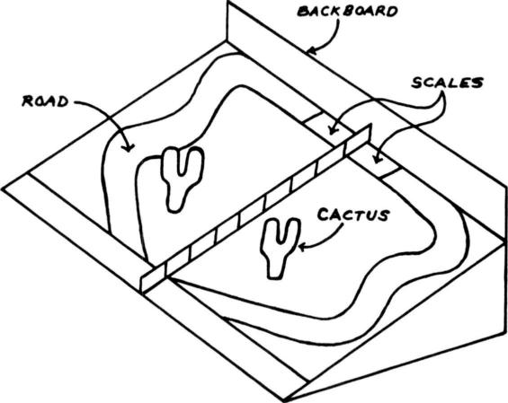

“我认为这条路绝对是必经之路，”其中一位说道。

"I think the road is definitely the way to go," one of them said.

我同意。“你所要做的就是建造一辆可以在路上行驶的小卡车；制造一个可以运载装满碎石的可乐瓶并在路上行驶的东西是很容易的，”我说，“或者你可以从下面走下去这里的‘仙人掌’，或者建造一辆绕着仙人掌行驶的宽阔越野车，或者像埃菲尔铁塔的电梯一样将重量举起的配重系统怎么样？”

I agreed. "All you have to do is build a little truck that goes up the road; it would be pretty easy to make something that carries a Coke bottle full of gravel and steers itself up the road," I said, "or you could go underneath the 'cactus' here, or build a wide off-road vehicle that goes around the cactus, or how about a counterweight system that lifts the weight up like the elevator in the Eiffel Tower?"

我们又聊了一会儿，他们也有很多想法。我回到办公室。炖菜已经开始煮了。

We talked a while longer, and they, too, had many ideas. I went back to my office. The stew had begun to simmer.

“你为什么不建造一个像起重机一样伸出手臂的东西呢？” 阿里提议道。他不仅驾驶过坦克，还设计过坦克，我很重视他的意见。伸出手臂会给问题增加另一个维度。我怎样才能将 41/2 英尺长的东西放入 2 英尺长的面包盒中？

"Why don't you build something that extends an arm out there like a crane?" Ari suggested. Not only had he driven tanks, he'd also designed them, and I valued his opinion. Extending an arm out would add another dimension to the problem. How could I fit something 41/2 feet long into a 2-foot-long bread box?

10 月 28 日

October 28

9:47 PM “消防车！” 当我走出斯隆实验室前往高级学院的路上时，我想到了这一点。我会建造一个伸缩梯，就像消防车上的梯子一样，它会将重量推到秤上。

9:47 P.M. "A fire truck!" It came to me as I walked out of the Sloan Lab on my way to Senior House. I'd build an extension ladder just like the ones on fire trucks, and it would push the weight onto the scale.

10 月 29 日

October 29

中午我去了消防队，看看这些东西在现实生活中是如何工作的。拉斐特广场有一辆钩梯卡车；卡车是 1941 年制造的，梯子是 1960 年安装的。那是一个巨大的铝制结构，我看了几乎一个小时所有的电缆和滑轮，但我一辈子都不明白它是如何工作的。肖内西中尉提出在周六早上帮我把梯子拿出来展示它的延伸，但周六是学习日，所以我只画了一些机制就离开了。

At noon I went to the fire department to see how these things work in real life. There was a hook and ladder truck at Lafayette Square; the truck had been built in 1941, and the ladder was mounted in 1960. It was a huge aluminum structure, and I looked at all the cables and pulleys for almost an hour and couldn't for the life of me figure out how it worked. Lieutenant Shaughnessy offered to take the ladder out for me on Saturday morning and demonstrate its extension, but Saturday was to be a study day, so I just sketched a few mechanisms and left.

11 月 5 日

November 5

全班160名学生被分成10个“背诵班”。这些课程每周举行一次，每次一小时，提供比大型讲座形式更多的互动教学。去年秋天，汤姆·布莱 (Tom Bligh) 教授对林德伯格的了解比我还多，我曾和他一起提议用风车和热泵为堪萨斯州的农舍供暖，他是我的背诵老师。他为班上160名学生中的约20人提供了个人咨询。汤姆将决定我的成绩。

The class of 160 students was divided into 10 "recitation sections." These met for an hour once a week for more interactive instruction than was available in the larger lecture format. Tom Bligh, the professor who'd known more about Lindbergh than I did the previous fall, and with whom I'd proposed to heat Kansas farmhouses with windmills and heat pumps, was my recitation instructor. He gave personal consultations to about 20 of the 160 students in the class. Tom would determine my grade.

每周与背诵老师会面的一个好处是它会迫使你做一些事情。这次会议有点像我们为斯隆实验室的研究赞助商准备的进度报告。所以前一天晚上我熬夜过了半夜，试图弄清楚如何建造我的消防车梯子。

One advantage of having a meeting with your recitation instructor every week is that it forces you to do something. The meeting was sort of like the progress reports we prepared for the research sponsors in the Sloan Lab. So I was up past midnight the night before, trying to figure out how to build my fire engine ladder.

“我会把木头切成三块等宽的条，然后把三块中的两块粘成L形梁。这样应该相当坚固，制作起来很容易，而且便宜。”我说。我和我的同学开始称材料便宜或昂贵，好像指定的“成本”具有真正的意义。

"I'll cut the wood into three strips of equal width, and then glue two of the three into an L-shaped beam. That should be fairly strong, it's easy to make and cheap," I said. My classmates and I had started calling materials cheap or expensive, as if the assigned "costs" had real meaning.

一些设计细节已经开始出现。我应该在梯子上放置多少个横撑/横档？应该多宽？我将如何延长它？是时候随心所欲了。从五个十字括号开始，看看是否足够。如果没有，就加更多。我开始给自己写越来越多的笔记。“只要构建这个东西，让它工作并进行测试，”我不断地告诉自己。所以周五晚上我用了环氧树脂和木头，以及一块 1 英寸厚的不锈钢，在环氧树脂硬化时将木头固定在一起。

Already little design details started popping up. How many cross braces/rungs should I put in my ladder? How wide should it be? How will I extend it? It was time to be arbitrary. Start with five cross braces and see whether that's enough. If not, put more in. I began to write more and more notes to myself. "Just build the thing, get it working and tested," I kept telling myself. So I spent Friday night with epoxy and wood, and a piece of stainless steel 1 inch thick to hold the wood together while the epoxy hardened.

11 月 6 日

November 6

我的 L 型钢效果非常好。环氧树脂硬化；我从来不相信木头可以这么硬。我预计八点钟就会有一群暴徒，于是我到达了蒂尼的商店，但大多数人都睡了，我找到了一台可用的钻床，可以在上面为我的铜棒钻孔。我在两只脚上放了五个横档，我再次对坚硬、轻盈的结果感到惊讶。

My L-beams came out really well. The epoxy hardened; I would never have believed wood could be that stiff. Expecting a mob at eight, I arrived at Tiny's shop, but most people slept in and I found an available drill press on which to drill the holes for my copper rods. I put five rungs in two feet, and again I was amazed at the stiff, light results.

花了一上午的时间才钻了二十个洞，当我完成时，这个地方已经开始跳动了。每个人的背包里都装满了木条和焊条；对于大多数人来说，这是施工的第一天。一些人建造了框架，一些人为 2 瓦电机建造了驱动系统，另一些人在车床上用砖石加工了车轮。

It took all morning to drill the twenty holes, and by the time I finished the place was hopping. Everyone had backpacks filled with wood strips and welding rod; for most of them it was the first day of construction. Some built frames, some built drive systems for their 2-watt motors, others machined wheels from masonite on the lathes.

到了 1:00，我的横梁和焊条开始看起来像梯子，有人说：“这是我见过的最好的赛道。”

By 1:00 my beams and welding rod began to look like a ladder and somebody said, "That's the best track I've seen yet."

我说：“谢谢，但这不是轨道，而是梯子。”

I said, "Thanks, but it's not a track, it's a ladder."

他说：“哦。好吧，不管它是什么，它都建得很好。”

He said, "Oh. Well, it's nicely built, whatever it is."

下午 2:00，我将绳子交错在梯子的横档之间，这样当我拉动一端时，绳子就完全伸展开来。有效！但当我对它施加重量时，它几乎没有延伸。

2:00 P.M., and I had my string interlaced among the rungs of my ladder so that it extended fully when I pulled on one end. It worked! But when I put a weight on it it hardly extended at all.

“解决重量支撑问题，”我在实验室笔记本上写道——这是一个多么大的问题。如果我将梯子瞄准秤，梯子末端和下面的地形之间就会有一个恒定的角度，但梯子末端的高度会随着爬山而变化。我确信我不想设计一个在爬坡时会收缩的车轮组件。是时候骑自行车了。

"Resolve weight support problem," I wrote in my lab notebook-and what a problem it was. If I aimed the ladder at the scale, there would be a constant angle between the end of the ladder and the terrain below, but the height of the ladder end would vary as it would climb the hill. I was sure I didn't want to design a wheel assembly that would contract as it climbed the hill. Time for a bike ride.

11 月 7 日

November 7

晚上 9:20 在我的机械制图作业中，我的目光无法从梯子上移开。我一直在想，我该如何支撑这个重量？梯子看起来很棒，但它永远不会像现在这样工作。必须有一种方法来支撑重量。

9:20 P.M. In the middle of my mechanical drawing assignment, I couldn't keep my eyes off the ladder. I kept thinking, How am I going to support that weight? The ladder looks great, but it will never work as is. There's got to be a way to support the weight.

然后它来了。灯泡出现在我的头顶上，我从办公桌抽屉里拿出了一些橡皮筋。为什么不用橡皮筋把梯子射出来，然后将重物绞到“轨道”上呢？

And then it came. The light bulb appeared over my head and I took some rubber bands out of my desk drawer. Why not shoot the ladder out with rubber bands, then winch a weight up the "track"?

中午 12:40，我还在床上翻来覆去，想着用不同的方法射出梯子和拉起重物：痴迷开始了。这个词获得了新的含义。这些信就像贝蒂·戴维斯电影的开头一样滴落下来，我意识到二七十分有我。

12:40 A.M., and I was still tossing and turning in bed with the ideas of different ways to shoot the ladder out and haul up the weight: obsession was beginning. The word obtained new meaning. The letters dripped as at the beginning of a Bette Davis movie and I realized that two seventy had me.

11 月 8 日

November 8

“现在这是一个很好的工程，”汤姆布莱在检查我的梯子时说道。“你知道，我不明白一些参加这门课程的人如何能够完成他们所做的草率的工作并与自己相处。对于工程师来说，除了高质量之外，应该没有其他的方法来做事。”

"Now this is a good piece of engineering," Tom Bligh said as he examined my ladder. "You know I don't see how some of the people who take this course can do the slipshod work they do and live with themselves. For an engineer, there should be no other way to do things than with high quality."

“嗯，我的优势是作为一名实验室技术人员有效地工作了近两年，我已经了解了如何正确设置和构建它们，”我说。我试图保持谦虚，但我意识到我所要做的就是继续做好工作，我就会获得第二个 A。

"Well, I've got the advantage of having effectively worked as a lab technician for almost two years, and I've seen how to set things up and build them right," I said. I tried to be modest, but I realized that all I had to do was to keep up the good work and I'd have my second A.

“是的，好吧，你还有很多事情要做，但没有太多时间去做，”他说，我同意了。“让我们尝试用恒力弹簧来射击它。”

"Yes, well you've still got a lot to do and not a lot of time to do it," he said and I agreed. "Let's try shooting this out with the constant force spring."

他卷起梯子，将一个舞台叠在另一个舞台上，弹簧完全伸展。“你站在我对面，”他说。“注意你的眼睛。” 当他放手时，我距离他大约五英尺。上面的舞台直接飞进了我的怀里。“我认为它有足够的流行度可以上山；你觉得怎么样？” 他问。

He wound up the ladder and put one stage on top of the other with the spring fully stretched. "You stand over there across from me," he said. "Watch your eyes." I was about five feet from him when he let go. The upper stage flew right into my arms. "I think it's got enough pop to go up the hill; what do you think?" he asked.

“我想我是在做生意，但还有很多事情要处理，”我说。

"I think I'm in business but have a lot of business to attend to," I said.

“尽快让它发挥作用，”他说。

"Just get it working as quickly as you can," he said.

11 月 9 日

November 9

任务：腿、止回机构、将重物拉上轨道的推车、滑轮、电机驱动系统、框架。细节，细节，细节，足以让你发疯。现在忘掉电子产品吧：它只值 500 克。但我也必须解决其他问题集，并且我必须在快速压缩机上的论文工作上保持一些表面上的进展。啊啊。所以这就是为什么麻省理工学院是美国最好的工程学院，这意味着世界上最好的工程学院。

Tasks: legs, nonreturn mechanism, cart to pull weight up track, pulley, drive system for motor, frame. Details, details, details, enough to drive you crazy. Forget electronics for now: it's only worth 500 grams. But I have to work on other problem sets, too, and I have to maintain some semblance of progress with my thesis work on the rapid compression machine. Aargh. So this is why MIT is the best engineering school in the United States, which means in the world.

晚上 9:00 “Ari，这对我来说已经成为一种困扰。我无法做任何其他事情或思考任何其他事情。有太多事情要做，我必须让事情顺利进行，但我的时间不多了。 ”

9:00 P.M. "Ari, it's becoming an obsession to me. I can't do anything else or think of anything else. There's so much to do, and I have to keep things rolling, and I'm running out of time."

“是的，就像咖啡一样，”他回答道。

"Yes, it's like co ca heen," he answered.

“像什么？”

"Like what?"

“可，你知道，你吸入它，”他用鼻子深深地吸了一口气，“你吸得越多，你想要的就越多。”

"Co ca heen, you know, you breathe it in," and he took a big breath through his nose, "and the more you breathe in the more you want."

“正是如此，”我一边说，一边回去查看我的机器。

"That's it exactly," I said as I went back to look at my machine.

11 月 10 日

November 10

是时候回顾一下预算了：恒力弹簧，500美元；木条，1,750 美元；纤维板，1,000 美元；电机，1,000美元；焊条，350 美元 ... 4,600 美元总计。还剩下将近8000美元。是时候计划第二天的事情了。有组织的拖延很有用，因为决定你要在机械车间做什么通常比实际执行要花更长的时间。

Time to review the budget: constant force spring, $500; wood strips, $1,750; masonite sheet, $1,000; motor, $1,000; welding rod, $350 ... $4,600 total. Almost $8,000 left. Time to plan for the next day. Organized procrastination is useful because deciding what you're going to do in a machine shop usually takes longer than doing it.

我必须设计那个框架。这很容易，但我无法克服阻止我解决这个子问题的惯性。不过，如果我能在明天晚上之前搭建好框架，我的状态就会很好。

I've got to design that frame. It's easy, but I can't overcome the inertia keeping me from that subproblem. If I can build the frame by tomorrow night, though, I'll be in good shape.

11 月 11 日

November 11

退伍军人节，我参加了核战争的教学吗？Nooooo00 ...正如约翰·贝鲁什（John Belushi）所说。我从事我的二七十项目。

Veteran's Day and did I go to the teach-in on nuclear war? Nooooo00 ... as John Belushi would have said. I worked on my two seventy project.

下午 4:00 我在大圆顶前等待沙拉三明治。一个三十七岁的留着胡须的男人走下台阶，朝波士顿走去。他穿着蓝色牛仔裤，从膝盖以下都是皮革和木头的。作为一名越战老兵，他为和平腾出了时间。

4:00 P.M. I waited for my falafel in front of the Great Dome. A bearded man, thirty-seven, walked down the steps toward Boston. He wore blue jeans and leather and wood from his knee down. A Vietnam veteran, he made time for peace.

9:00 PM “你知道会造成什么样的破坏吗？” 阿栗语气激烈的说道。“这会让你至少倒退 100 年。从本质上讲，你是靠前几代人的工作生活的。决不能发生核战争。”

9:00 P.M. "Do you realize what destruction there would be?" Ari said vehemently. "It would set you back at least 100 years. Essentially you are living on the work of all the generations before you. There must not be a nuclear war."

我有点惊讶，因为我认为阿里，我认识的最坚定的反苏鹰派，会向我保证，这些武器是将熊关在笼子里所必需的。“更重要的是，”他说，“那里没有人，没有学生，没有人。你们根本不关心这个吗？这可能是世界末日，那里也没有人。”

I was a little surprised because I thought Ari, the staunchest anti-Soviet hawk I knew, would assure me that the weapons were necessary to keep the bear in its cage. "And what's more," he said, "there was nobody there, no students, nobody. Don't you people care at all about this? It could be the end of the world and there'd be no one there."

“但我有我的二七十项目要担心，”我说。“明年我还会去那里。”

"But I have my two seventy project to worry about," I said. "I'll be there next year."

“明年将会是另一回事。”

"Next year it will be something else."

11 月 12 日

November 12

参赛者带着看起来像机器的设备来到机械车间。越来越少的人携带装着木条的背包，越来越多的人携带装有部分完成的设备的盒子。我当时还处于背包阶段。

Contestants arrived at the machine shop with machinelike-looking devices. Fewer and fewer carried backpacks with wood strips in them, and more and more carried boxes with partially completed devices. I was still at the backpack stage.

下午 3:00 布莱教授外出，因此我与格里菲斯教授进行了交谈。他把自行车停在海伍德、韦尔和威尔逊的旁边。和他们一样，他也为能源行业提供咨询服务。和他们一样，他也骑自行车上班，因为他重视效率。他说：“关键是，你可以在这个项目上花两个小时，制作一个弹射器，然后把重量放在秤上，或者你可以花两年的时间，把太空计划的努力投入其中。我们试图教你根据有限的时间和资源做出决定。这就是现实世界一直以来的样子。”

3:00 P.M. Professor Bligh was out, so I spoke with Professor Griffith. He parked his bicycle next to Heywood's, Weare's, and Wilson's. Like them, he consulted to the energy industry. Like them, he bicycled to work because he valued efficiency. He said, "The point is, you could spend two hours on this project, make a catapult, and put a weight up on the scale, or you could spend two years on it, and put the effort of the space program into it. We're trying to teach you to make decisions based on limited time and resources. That's what the real world is like all the time."

晚上 7:00 放松时间。我想知道这门课程导致了多少人精神崩溃。我的个人日程和目标有所下滑。我必须构建那个框架，但它涉及太多细节，我不知道从哪里开始。

7:00 P.M. Freak-out time. I wondered how many nervous breakdowns this course had produced. I was slipping on my personal schedule and goals. I had to build that frame, but it involved so many details I didn't know where to start.

我和阿里谈过。“冷静点，”他说。“到目前为止，你已经做得很好了。继续保持下去，不要让压力压倒你。”

I talked to Ari. "Calm down," he said. "You've done good work so far. Just keep it up and don't let the pressure overwhelm you."

“你说得对。但今晚我太紧张了，无法思考。我必须去滑冰。” 于是我就去了溜冰场。那里大约有一百名滑冰者，冰真的被切碎了——在赞博尼人将其清理干净后仅十五分钟。赞博尼对我来说看起来更容易理解。我想把它拆开，看看它的每一个小部件是如何工作的。

"You're right. But tonight I'm so wound up I can't think. I've got to go skating." So I went to the rink. There were about a hundred skaters there and the ice was really chopped up-only fifteen minutes after the Zamboni had cleaned it off. The Zamboni looked more comprehensible to me. I wanted to take it apart and see how every little piece of it worked.

那里有很多滑冰者，突然开始和停止。对于麻省理工学院的学生来说，滑冰就像磨牙一样，而冰球是最受欢迎的校内运动。经过五十圈艰苦的比赛后，我去了高级之家，度过了一周以来最好的一晚睡眠。

There were many skaters there, starting and stopping abruptly. Skating is like grinding one's molars together for MIT students, and ice hockey is the most popular intramural sport. After fifty hard laps, I went to Senior House for my good night's sleep of the week.

11 月 13 日

November 13

下雨。谢天谢地，否则我可能会放弃一整天的自行车来避免做我的项目。我上了3号楼楼上练习跑道的地方。房间里还有另一个人。他有一台带有大砖石轮子和木制轮毂的机器，正试图让他的抓钩抓住篮板，并将卡车绞到秤上。

Raining. Thank goodness for that, or I'd have probably blown the whole day cycling to avoid working on my project. I went upstairs in Building 3 to where the practice track had been set up. There was one other guy in the room. He had a machine with big masonite wheels and wooden hubs and was trying to make his grappling hook catch the backboard and winch his truck up to the scale.

我必须构建框架。这意味着：计算出要切割的木块的高度并切割它们。然后列出任务清单。1. 切割两块 3-5/s 英寸的碎片。2. 切两块 5 英寸/2 英寸的块。3. 切两块 73/16 英寸长的块。4. 环氧树脂拼凑在一起。5. 切割焊条。6. 切出间隙间隙。在这种事情上保持理智的唯一方法就是列出清单，然后核对掉。

I had to build the frame. That meant: figure out heights of wooden pieces to cut and cut them. Then make a list of tasks. 1. Cut two 3-5/s-inch pieces. 2. Cut two 5-'/2-inch pieces. 3. Cut two pieces 73/16 inches long. 4. Epoxy pieces together. 5. Cut welding rods. 6. Cut notches for clearance. The only way to keep your sanity in this kind of thing is to make lists and then check things off.

学生机械车间全天开放，3号楼的地下室没有失业人员。每台车床、每台带锯、每台铣床、每台钻头都在不断使用。战时。创新研究、开发、制造只需几分钟、几小时。只剩下120个小时了。没有时间拖延了。二七十分是有机化学工程实验室。有机实验室给医学预科生手术室压力；两点七十分给工程师生产线带来压力。人们开始互相问：“这有效吗？” 每次听到这个问题，我都会更加坚定地致力于使其发挥作用。

The student machine shop was open all day and there was no unemployment in the basement of Building 3. Every lathe, every bandsaw, every milling machine, every drill was in constant use. Wartime. Innovations researched, developed, manufactured in minutes, hours. Only 120 hours left. No time to procrastinate. Two seventy is the organic chemistry lab of engineering. Organic lab gives premeds operating room pressure; two-seventy gives engineers production line pressure. People began to ask one another, "Does it work?" Each time I heard the question my commitment to make it work was heightened.

晚上 9:30，我坐在男洗手间（3-126），感觉到整个建筑都因地下室机器的嗡嗡声而振动。每次从地下室车间到四楼试验场的楼梯上上下下，前一年最好的机器的展示都会引起我的注意。他们就在米基奇办公室对面的箱子里；我今年最好的机器将在一月份到达。我变得不那么累了。

9:30 P.M. I sat in the men's room (3-126) and felt the whole building vibrate from the whirr of the machines in the basement. On each trip up and down the stairs from the workshop in the basement to the testing ground on the fourth floor, the display of the best machines from the year before caught my eye. They were in the case across from Mikic's office; the best machines from my year would be there in January. I became less tired.

晚上 11:00 所有机器都关闭的时刻。我错过了噪音。有人打开了带锯。

11:00 P.M. A moment when all machines were off. I missed the noise. Someone turned on the bandsaw.

11 月 14 日

November 14

要做的事：午餐后在图书馆阅读周日漫画。在延伸部分钻孔，以便在其飞散时接住它。将底座粘在一起。需要做的事情还很多。有很多琐碎的细节需要注意。

To do: Read Sunday comics in library after lunch. Drill holes in extension to catch it as it flies apart. Glue base together. So much to do. So many piddly details to attend to.

晚上 8:50 我需要家人的支持，所以我打电话回家。

8:50 P.M. I needed familial support so I called home.

“我有一些悲伤的消息要告诉你，佩珀，”我母亲说。“你的狗刚刚死了。”

"I have some sad news for you, Pepper," my mother said. "Your dog just died."

为什么它必须同时发生？为什么我不等到比赛结束后才打电话，这样我就不用担心这个问题了？挂断电话后，我踢了一个塑料饼干托盘，它碎了。

Why does it have to happen all at once? Why didn't I wait until after the contest to call so I wouldn't have to worry about this? After I hung up, I kicked a plastic cookie tray and it shattered.

阿里跑到我的办公室，发现我在哭泣。“你必须重新掌控局面。这里的教授们并不关心你发生了什么事；他们只关心你产出了什么。现在去洗个澡，然后回去工作。你必须完成你已经开始的工作。 ” 他说得好像我是他的一名受到炮弹休克的士兵一样。他很坚定，我对此表示赞赏。

Ari ran over to my office and found me sobbing. "You have to get back in control. The professors here don't care what happened to you; they just care about what you produce. Now go and wash yourself and go back to work. You must finish the job you've started." He said it as if I were one of his soldiers who was shellshocked. He was firm, and I appreciated it.

12:30 AM 框架完成。我比计划晚了一天，但至少我可以睡觉了。

12:30 A.M. The frame was complete. I was one day behind schedule, but at least I could sleep.

11 月 15 日

November 15

上午去上课；PM，从事电子工作。

A.M. go to class; P.M., work on electronics.

“如何使用这个绕线工具？” 我问辛迪。

"How do I use this wire-wrap tool?" I asked Cindy.

“这很容易，”她一边说，一边用这个工具将两根电线固定在我芯片上的引脚周围。“好了。你现在就试试吧。”

"It's easy," she said as she used the tool to fix two wires around pins on my chip. "There. You try now."

很容易。技术的另一个谜团对我来说已经消失了。辛迪完成了电路的接线，另一位本科生向我寻求帮助。

It was easy. Another mystery of technology had vaporized for me. Cindy finished wiring her circuit, and another undergraduate woman asked me for help.

“这很容易，”我说，然后我向她展示了如何连接电线。她很漂亮，我提醒自己，当我还是一年级学生时，她才六年级——别想约她出去约会。

"It's easy," I said, and I showed her how to attach the wire. She was beautiful, and I reminded myself that when I was a freshman she was in sixth grade-don't even think of asking her out on a date.

下午 6:30 重新接线 3 次后，我的电路终于工作了。如果不出意外的话，我会赢得 500 克的额外重量。

6:30 P.M. After rewiring it three times, my circuit finally worked. If nothing else, I would win the 500-gram bonus weight.

11 月 16 日

November 16

我的机械制图测试直观而简短，但不幸的是我没有收到第二页，必须稍后在布莱的办公室完成测试。就在我开始认为自己很聪明的时候。我已经完成了框架、电子设备和梯子。剩下的就是构建驱动系统。那么如果这是最难的部分呢？我的钱快用完了。我买不起商店出售的现成棒的“成本”，所以我不得不拒绝车床上更便宜的方棒。这只需要三个小时。我不仅是发明家、研究员、生产线工人、成本会计；我是一位微观经济学家，用时间——即劳动力（即我的睡眠）——来交换资本，即现成商品。

My mechanical drawing test was intuitive and short, but unfortunately I didn't receive page two and would have to finish the test later in Bligh's office. Just when I was beginning to think I was smart. I'd completed the frame, the electronics, the ladder. All that remained was to build the drive system. So what if that would be the hardest part? I was running out of money. I couldn't afford the "cost" of the ready-made rods that the store sold, so I'd have to turn down a cheaper square bar on the lathe. That would take only three hours. Not only was I inventor, researcher, production line worker, and cost accountant; I was a micromicroeconomist trading time-i.e., labor (i.e., my sleep)-for capital, i.e., readymade goods.

四小时后，我完成了轴的加工。

Four hours later I finished machining the shaft.

11 月 17 日

November 17

上午 7:00 距离第一次审判还剩 36 小时。我很早就去了斯隆实验室，这样我就可以招募尼克来帮助我设置实验室的车床，为我的驱动轮加工镁森石。

7:00 A.M. Thirty-six hours left until the first trials. I went to the Sloan Lab early so I could recruit Nick to help me set up the lab's lathe to machine the masonite for my drive wheel.

9:55 AM 去拿计算器和书籍，进行剩下的机械制图考试。我对自己说：“假装你在西点军校，每天都有考试。”

9:55 A.M. Go to pick up calculator and books for rest of mechanical drawing test. I said to myself, "Just pretend you're at West Point and you always have a test every day."

上午 10:45 返回尼克处寻求更多帮助。

10:45 A.M. Back to get more help from Nick.

中午 12:10 尼克去吃午饭。

12:10 P.M. Nick went to lunch.

下午 1:20 还剩 30 个小时。由于驱动系统无法正常工作，我无法毁掉所有东西。这台机器看起来太棒了，不能错过决赛。我必须完成它。要做的事： 1. 将电线焊接到电机引线上。2. 转动电机轴。3、搭建驱动系统。4. 制作传动系统轴承。5、搭建驱动系统。为了强调，我写了两遍。

1:20 P.M. Thirty hours left. I can't blow everything because of a nonfunctioning drive system. The machine looks too good to miss the finals. I've got to finish it. To do: 1. Solder wires to motor leads. 2. Turn down motor shaft. 3. Build drive system. 4. Make bearings for drive system. 5. Build drive system. I wrote it twice for emphasis.

我知道我每小时都需要。我太紧张了，无法焊接电线，所以我做了一点小作弊，玛丽冷静地很快帮我焊接了它们。

I knew I'd need every hour. I was so nervous I couldn't solder the wires, so I cheated a little bit and Mary calmly, quickly soldered them for me.

晚上 8:00 我开玩笑地问助教奈杰尔·亚当斯 (Nigel Adams)，“你打算让 2 点 70 分的机械车间通宵营业吗？” 我一半希望他说“不”，这样我就可以睡一会儿，一半希望他说“是”，这样我就可以战斗到最后一刻。

8:00 P.M. I jokingly asked Nigel Adams, the teaching assistant, "Are you going to keep the two-seventy machine shop open all night?" I half-wanted him to say no so I could get some sleep, half-wanted him to say yes so I could fight to the wire.

“是的。'

"Yes.'

11:00 PM 机械车间有 15 个人，更不用说 Tiny 车间的 10 个人以及楼上赛道上的 10 个人测试；有人带来了一个音箱来让我们度过整夜的帮派。人们一起放声歌唱。你可以在机器的嗡嗡声中听到他们的声音。

11:00 P.M. Fifteen people in the machine shop, not to mention ten in Tiny's shop and ten upstairs testing at the track; somebody brought in a boom box to keep us going through the gang-allnighter. People sang along at the top of their lungs. You could just hear them over the whirr of the machines.

凌晨 2:00 两个轴均已完成。是时候调小驱动轮以使其安装在轴承中了。

2:00 A.M. Both shafts done. Time to turn down the drive wheel to make it fit in the bearing.

凌晨 3:30 将驱动轮压装到轴上。快速决定钻头尺寸。

3:30 A.M. Press fit drive wheel onto shaft. Make quick decision on drill sizes.

4:00 AM 轮子在轴上。如果您熬到凌晨 4:00，夜幕即将降临。我遇到了艾迪，他是前一年阻止我伤害自己的看门人。“没时间说话，艾迪，我稍后再找你。”我说。

4:00 A.M. The wheel was on the shaft. If you make it to 4:00 A.M., the back of the night is broken. I met Eddy, the janitor who'd kept me from hurting myself the year before. "No time to talk, Eddy, I'll catch up with you later," I said.

上午 6:30 我的轮轴在我通过在一块黑色聚四氟乙烯上钻一个孔制成的轴承中轻松移动。还有希望。是时候清理一下了，这样没人会知道我们三十五个人整晚都在那里。该机构的保险公司会怎么说？

6:30 A.M. My wheel's axle moved easily in the bearing I'd made by drilling a hole in a piece of black Teflon. There was hope. Time to clean up so nobody would know the thirty-five of us were there all night. What would the institute's insurance company say?

8:00 AM 早餐甜甜圈和酸奶。

8:00 A.M. Doughnut and yogurt for breakfast.

上午 8:15 午睡时间。

8:15 A.M. Nap time.

11 月 18 日

November 18

我的数字闹钟显示 12:50，而我的考试时间是中午。哎呀！一秒钟就穿上衣服，跑过校园。在我的实验室里我看不懂时钟。看起来像是 11:30，但又有点像 12:30，我无法区分三个小时的睡眠。“冷静点，”我对自己说。“叫时间吧。”

My digital alarm clock said 12:50 and my test was at noon. Aieeee! Get into clothes in a second and run across campus. At my lab I couldn't read the clock. It looked like 11:30, but sort of like 12:30 and I couldn't tell the difference on three hours' sleep. "Calm down," I said to myself. "Call the time."

“听到提示音后，时间将是 11 点 32 分 20 秒。”

"At the tone the time will be 11:32 and 20 seconds."

1:30 PM Chet 有时可能会很粗鲁，但内心深处他是一个好人。我向切特寻求驱动系统方面的帮助。

1:30 P.M. Chet could be rough around the edges at times, but deep down inside he was a good guy. I asked Chet for help with the drive system.

这是他表现出乐于助人的时候之一。“就这样把它拼起来，然后用5分钟的环氧树脂粘合起来，”他说，我们两个人在2:00之前完成了施工。

This was one of the times his helpfulness showed through. "Just put it together like this and glue it with 5-minute epoxy," he said, and the two of us finished construction before 2:00.

下午 3:00 我在 Lobdell 遇见了 Cindy Brooks。她端着一个托盘，里面有五个三明治，她坐在我的桌子旁。

3:00 P.M. I met Cindy Brooks at Lobdell. She had a tray with five sandwiches and she sat at my table.

“我希望你能坐在这里，”我说。

"I was hoping you'd sit here," I said.

“呃。哦，哎呀，我就随便坐。” 她很尴尬。下次不要表现得这么强势，我想。

"Uh. Oh, gee, I just sit wherever." She was embarrassed. Next time don't come on so strong, I thought.

“为什么要这么多三明治？” 我问。

"Why so many sandwiches?" I asked.

“这是我接下来三十个小时的食物，”她回答道。“我的初赛是明天。”

"This is my food for the next thirty hours," she answered. "My preliminary round is tomorrow."

“好吧，祝你好运。待会儿见。”我说。

"Well, good luck. See you later," I said.

下午 4:00 驱动系统运行！

4:00 P.M. Drive system operational!

下午 5:00 在赛道上进行测试。梯子没有按照应有的方式展开。下楼并设置止动件。我总是错误地穿线，并且各部分相互卡住。但它有潜力。绳子缠绕在绞盘轴上，就像真正的绞盘一样。

5:00 P.M. Testing on the track. The ladders didn't deploy the way they should. Go downstairs and put stops in. I kept threading the string wrong, and the sections jammed against each other. But it had potential. The string wound around the winch shaft just like on a real winch.

晚上 7:00 预选赛，第一轮。另一位背诵导师布兰科教授说：“我们只是想看看周一很有可能发挥作用的东西。” 更多希望。

7:00 P.M. Trials, round one. Professor Blanco, another recitation instructor, said, "We just want to see something that has a good chance of working on Monday." More hope.

我的第一轮。梯子出去了，但当它伸展时，它因自身重量而倒塌。我下楼做支撑来接住它。

My first round. The ladder went out but as it extended it fell under its own weight. I went downstairs to make supports to catch it.

8:00 PM 制作支撑。我该怎么做？我没有时间。我厌倦了做出所有这些愚蠢的决定。钻头在哪里？我制作棒需要多长时间？哎呀！啊啊！我不得不离开商店，撞到墙上，靠着墙站着，尽量不让自己流泪。这个愚蠢的事情几乎起作用了。如果我没有进入决赛，那么我所花费的所有时间都被浪费了。然后……冷静下来。您所要做的就是钻几个孔并放入一些焊条。今晚就这样了。

8:00 P.M. Make supports. How do I do it? I don't have time. I'm sick of making all these stupid decisions. Where are the drill bits? How long do I make the rods? Aieee! Aargh! I had to leave the shop, hit the wall, and stand against it and try not to burst into tears. The stupid thing almost works. If I don't make it to the finals all the time I've spent is wasted. Then ... Calm down. All you have to do is drill a couple of holes and put some welding rod in. That'll do for tonight.

我做到了，它也做到了。梯子没有达到规模，但它已经足够让我保持在希望的舞台上。

I did and it did. The ladder didn't make it to the scale but it went far enough to keep me in the arena of hope.

11:00 PM 我走下楼梯，遇到了一位看上去很年轻的大二学生。

11:00 P.M. I walked down the stairs and encountered a youngish looking sophomore.

“嗅探嗅探。”

"Sniff, sniff."

“怎么样了？” 我戴上“导师”帽子问道。

"How's it going?" I asked, putting on my "tutor" hat.

“这不起作用，”然后抽泣变成了抽泣。

"It doesn't work," and the sniffs became sobs.

“你的审判什么时候进行？”

"When's your trial?"

“明天，我已经连续三个晚上没睡了，还是不行。”

"Tomorrow. I've been up all night for the past three nights and it still doesn't work."

我怎么知道你的感受，我想。“我知道你正在经历什么。如果不可能让整个事情正常运转，为什么不在接下来的几个小时内设定一些个人目标；比如说，尝试让一两个子系统正常工作。”

How I know how you feel, I thought. "I know what you're going through. If it's not possible to make the whole thing work, why don't you set some personal goals for the next few hours; say, try to get one or two subsystems to work."

“我已经从这个愚蠢的课程中得到了我想要的一切。”

"I've already gotten all I want to out of this stupid course."

懦夫。

Wimp.

辛迪在楼下商店外面，旁边是一个航空工程部的人。

Cindy was downstairs, outside the store, working next to a guy from the Aeronautical Engineering department.

“我不敢相信这个部门的人们如此友好，”她说。

"I can't believe how friendly people are in this department," she said.

“也许是因为我们比你们航空业的人有更广泛的职业选择，”我说。

"Maybe it's because we have wider career options than you aero guys," I said.

“是的，就像制造烤面包机而不是杀手卫星一样，”辛迪补充道。“或者玩具。在美泰玩具公司工作不是很有趣吗？”

"Yeah, like making toasters instead of killer satellites," Cindy added. "Or toys. Wouldn't it be fun to work for Mattel Toys?"

我一生中第一次想到，如果我愿意的话，我可以为美泰玩具公司工作。

For the first time in my life I thought I could work for Mattel Toys if I wanted to.

11 月 19 日，星期五

Friday, November 19

休息日，以及处理被忽视的细节的时间，例如支付账单。

Rest day, and time to catch up on neglected details, e.g., paying bills.

11:00 PM 滑冰结束。体育中心的牌匾听起来很真实：“不是猎物，而是追逐；不是桂冠，而是比赛”（Burgess，1885）。

11:00 P.M. Finished skating. The plaque in the athletic center rang true: "Not the quarry but the chase; not the laurel but the race" (Burgess, 1885).

'大约午夜时分。我把梯子的横档喷成银色。如果没有其他的话，看起来会很好。

'Round midnight. I spray-painted the ladder rungs silver. It would look good if nothing else.

11 月 20 日

November 20

这本来应该是我骑自行车的一天，因为我的设备应该可以工作，但布莱建议我将设计更改为后面有铰链、前面有独轮手推车轮子的梯子。这可能会解决因自重而坠落的问题。

This was supposed to be my day for cycling because my device was supposed to work, but Bligh suggested I change the design to a ladder with a hinge at the back and a wheelbarrow wheel on the front. That might solve the falling-under-its-own-weight problem.

这意味着： 1. 打破我上周末建造的美丽底座上的环氧树脂粘合。2. 为梯子的前部制作一个轮子组件。这是很多工作，但却是我唯一的机会。布兰科教授曾说过，他花了七年时间开发出一种产品，却被一家德国公司偷走了。“你必须能够改变，”他说。“你投入了如此多的工作，边抱怨边想，‘但是改变需要很长时间......我已经做了很多......我不想改变它。’ 但你必须保持灵活性，愿意忘记你在一条路上花费的所有时间，然后转身走另一条路。否则，你将无法生存。”

So that means: 1. Break epoxy bonds on the beautiful base I built last weekend. 2. Build a wheel assembly for the ladder's front. It was a lot of work but my only chance. Professor Blanco once said that he spent seven years developing a product only to have it stolen by a German company. "You have to be able to change," he said. "You put in so much work and you think as you whine, 'But it will take so long to change ... I did so much already ... I don't want to change it.' But you have to be flexible, willing to forget about all the time you spent going one way, and then turn around and go another way. Otherwise, you will not survive."

4:00 PM 辛迪的机器是一款抓钩发射器，其结构质量首屈一指，甚至是我的。“你能成功吗？” 我问她。

4:00 P.M. Cindy's machine was a grappling hook launcher with a quality of construction second to none, even mine. "Are you going to make it?" I asked her.

“我希望如此，但今晚和明天晚上我几乎整个晚上都会在这里，”她说。

"I hope so, but I'll be here almost all night tonight and tomorrow night," she said.

“这是一台漂亮的机器。你真的应该冲刺让它工作。你有四十八小时，然后你就可以睡觉了，”我说。

"It's a beautiful machine. You should really sprint to make it work. You've got forty-eight hours and then you can sleep," I said.

晚上 9:00 我必须弄清楚如何为愚蠢的梯子前面制作愚蠢的轮子，所以我不得不上楼。那个周日之前举起八磅重的家伙也拿着他的抓钩在那儿。他正在和一位第六课极客交谈。

9:00 P.M. I had to figure out how to make the stupid wheel for the front of the stupid ladder, so I had to go upstairs. The guy who'd pulled up eight pounds the Sunday before was there with his grappling hook. He was talking to a Course Six geek.

“我认为设计是我的强项之一，”他说。

"I think design is one of my strong points," he said.

闭嘴，你这个书呆子。

Shut up, you nerd.

“你的周四不起作用，是吗？看起来不错，但不起作用，”他一边说，一边看着我试验梯子支撑的高度。

"Yours didn't work Thursday, did it? It looks good but it didn't work," he said as he watched me experiment with the heights of my ladder supports.

“这会起作用的，”我说，他的斥责让这件事变得更加迫切。这种事情是判断你是否是A型人的好方法。

"It'll work," I said, and his chiding made it more imperative. This kind of thing is a good way to tell whether you're a Type A.

他继续与他的朋友交谈。“我父亲去了哈佛。我进去了，但我不想去那里。我想如果我去麻省理工学院，我会更像一名工程师。他很失望。”

He continued his conversation with his friend. "My dad went to Harvard. I got in there but I didn't want to go there. I figured I'd be more of an engineer if I went to MIT. He was disappointed."

“我爸爸是麻省理工学院的立方，”另一个说。“他现在在 Draper 工作。你永远猜不到我妈妈去了哪里。”

"My dad's MIT cubed," the other one said. "He works at Draper now. And you'll never guess where my mom went."

“西蒙斯？” 八磅重的家伙说道。

"Simmons?" the eight-pound guy said.

“你说对了。”

"You got it."

“你现在正在和一个西蒙斯女人约会吗？” 抓钩先生问道。

"Are you dating a Simmons woman now?" Mr. Grappling Hook asked.

“没有，但我在那里参加了很多聚会。”

"No, but I go to a lot of parties there."

“不是要转移话题，但这堂课让你和所有熬夜的人变得像家人一样。这很有趣，”我离开房间时 GH 说道。

"Not to change the subject, but this class makes you become like family with all the people you stay up all night with. It's kind of fun," G.H. said as I left the room.

周日早上 1:00。我必须粘住这个轮子，但我不知道如何制作。仅仅决定如何切割一块木头就需要很长时间。此外，所有的钻头都没有标记，所有的尺子和千分尺都被刷过，所以我必须目视一切。另外，我想睡觉。

1:00 A.M. Sunday morning. I've got to glue this wheel but I don't know how to make it. It's taking forever just to decide just how to just cut just one piece of wood. Besides, all the drills are unmarked and all the rulers and micrometers have been swiped so I'll have to eyeball everything. Besides, I want to go to sleep.

跟它对干。坚持下去。只要让事情发挥作用即可。别担心有多好。只要让它发挥作用即可。只需切割木块并将它们粘在一起即可。在砂带磨光机上制作轮子。如果它看起来像《摩登原始人》中的东西又怎么样？它仍然比什么都没有好。

Fight it. Stay with it. Just make the thing work. Don't worry about how well. Just make it work. Just cut the pieces of wood and glue them together. Make the wheel on the belt sander. So what if it looks like something from "The Flintstones"; it's still better than nothing.

4:00 AM 环氧树脂正在凝固，车轮看起来不错。设计变成了我，我也变成了设计。

4:00 A.M. The epoxy was setting and the wheel looked good. The design had become me, and I had become the design.

11 月 21 日

November 21

下午 2:00 距离 26-100 比赛还剩 29 小时。辛迪说：“你听说昨天在哈佛发生的事情了吗？在橄榄球比赛中，在一次达阵后，一根小管子从球场上伸出来。然后一个气球开始膨胀。它是黑色的，上面写着麻省理工学院到处都是。最后它爆炸了，冒出黄色的烟雾。它登上了全国每家报纸的头版。这一定是本世纪的黑客事件。一些二七十岁的人被卷入其中。它。”

2:00 P.m. Twenty-nine hours left before the contest in 26-100. Cindy said, "Did you hear about what happened at Harvard yesterday? At the football game, right after one of the touchdowns, a small pipe sprang out of the field. Then a balloon started inflating. It was black, and it had MIT written all over it. Finally it blew up and yellow smoke came out of it. It was on the front page of every newspaper in the country. It's got to be the hack of the century. Some of the people in two-seventy were in on it."

麻省理工学院得一分。

Score one for MIT.

7:00 PM 辛迪看着她的抓钩发射器。“我很沮丧，”她说。“这是行不通的。这东西会不断分裂，轴承也会掉下来。”

7:00 P.M. Cindy looked at her grappling hook launcher. "I'm so depressed," she said. "It's not going to work. This thing keeps splitting and the bearings fall out."

“为什么不尝试将木头转动 90 度，这样轴承就不会试图将其分开？” 我建议。

"Why don't you try turning the wood 90 degrees so the bearing won't be trying to break it apart?" I suggested.

“这是个好主意。但我的驱动系统还需要一根橡皮筋，但没有像我拥有的那样的橡皮筋了，我必须去 Pritchett 小吃店工作，我已经筋疲力尽了。”

"That's a good idea. But I also need a rubber band for my drive system and there aren't any left like the one I had and I have to go work at the Pritchett snack bar and I'm exhausted."

“听着，你现在不能放弃。如果你这样做了，你永远不会原谅自己，”我说。

"Look, you can't give up now. You'll never forgive yourself if you do," I said.

“我会考虑一下。”

"I'll think about it."

10:30 PM 我和 Ari 聊了麻省理工学院的薪酬政策。我打开办公桌抽屉，发现十根各种尺寸和形状的橡皮筋。我去找普里切特把它们交给辛迪，但她已经下班了。她在自己的宿舍里。

10:30 P.M. I chatted with Ari about pay policy at MIT. I opened my desk drawer and found ten rubber bands of all sizes and shapes. I went to Pritchett to give them to Cindy but she was already off work. She was in her dorm room.

“我找到了这些，并认为它们可能会有所帮助，”我说。她仔细检查了一遍，找到了一个最完美的。

"I found these and thought they might help," I said. She looked through them and found one that was perfect.

“哇哦。这些太棒了。非常感谢。”

"Oh wow. These are great. Thanks a lot."

凌晨 1:10 距离发射还有十八个小时。不要放弃！我把它写在我的实验书里，以让我继续前进。两名学生在工作时戴着随身听。我想知道他们如何才能集中注意力。

1:10 A.M. Eighteen hours to launch. Don't quit! I wrote it in my lab book to keep me going. Two students wore Walkmen while they worked. I wondered how they could concentrate.

凌晨 3:00 开始测试。另外十个人正在测试他们的机器。我的几乎要跳起来了；打火石轮运转良好，但绳索摩擦力太大，导致电机停转。

3:00 A.M. Started testing. Ten other people were testing their machines. Mine almost sprang up; the Flintstone wheel worked nicely, but there was too much friction in the rope and the motor stalled.

凌晨 4:30 辛迪到达测试跑道。

4:30 A.M. Cindy was at the test track.

5:00 AM 尝试弹簧和绳子的不同组合；我把绞盘的绳子拧紧了两次。八磅重的GH先生走了进来。

5:00 A.M. Try different combinations of springs and string; I screwed up the threading of the string for the winch twice. Mr. eight-pound G.H. walked in.

“我以为这里不会有人，”他说。

"I thought there'd be nobody here," he said.

“承认吧，你只是来这里幸灾乐祸的。”我冷笑道。

"Admit it; you just came here to gloat," I sneered.

上午 6:30 试验继续进行，但机器仍然无法工作。在上次试验中，我错误地加载了弹簧。那次试验失败后我必须击中一些东西，而一盒电脑卡是最接近的东西。我试着把它们按顺序放回盒子里，并告诉自己在比赛结束后在盒子上留下一张纸条。7:00，我把八个人留在测试室，给机器喷了一层红色喷漆。

6:30 A.M. Trials proceeded but the machine still didn't work. On the last trial I misloaded the springs. I had to hit something after that trial failed, and a box of computer cards was the closest thing. I tried to put them back in the box in order, and told myself to leave a note on the box some time after the contest. I left eight people in the testing room at 7:00 and gave the machine a coat of red spray paint.

11 月 22 日

November 22

十九年前，约翰·菲茨杰拉德·肯尼迪遇刺身亡。

Nineteen years ago John Fitzgerald Kennedy was assassinated.

上午10点30分，电话响了。是汤姆·布莱。“你的机器运转正常吗？” 他问。“我必须列出今晚的名单，如果在 2:00 之前还没有成功，你就无法进入决赛。”

10:30 A.M. The phone rang. It was Tom Bligh. "Is your machine working?" he asked. "I have to make the list for tonight, and if it doesn't work by 2:00 you won't be in the finals."

“如果你没有打电话，肯定不会成功，因为我会睡一整天。我想我可以在 2:00 之前完成它。” 我回到赛道，四十个人在那里，进行最后一刻的调整、测试，并进行更多最后一刻的调整。“Oh s-”、“Oh f-”以每分钟约二十次的频率发出。

"If you hadn't called, it surely wouldn't have worked because I would have slept all day. I think I can make it work by 2:00." I went back to the track and forty people were there, making lastminute adjustments, testing, and making more last-minute adjustments. "Oh s-," "Oh f-," emanated at a frequency of about twenty times per minute.

我重新进行了前一天晚上中止的审判。几乎，几乎达到了这个规模，布兰科教授印象深刻。汤姆·布莱走进来，另一个灯泡在我头顶亮了起来。“我成为安慰剂之一怎么样？” 我问。“再给我一根弹簧，我的机器就能完美工作了。”

I reran the aborted trial of the night before. It almost, almost reached the scale and Professor Blanco was impressed. Tom Bligh walked in, and another light bulb lit over my head. "How about I be one of the placebos?" I asked. "Let me have one more spring and my machine will work perfectly."

由于比赛是一对一的淘汰赛，就像网球锦标赛一样，因此有些回合的参赛者人数可能是奇数，或者有些缺席。两七十的传统不是让任何人通过“再见”幸运地进入下一轮，而是有一个“安慰剂”，一个可以对抗无对手玩家的条目。就像糖丸一样，安慰剂不是正式的参赛者，但它可能有效。

Since the contest was a one-on-one elimination like in a tennis tournament, some rounds would have an odd number of contestants, or some no-shows. Instead of letting anyone luck into the next round by a "bye," two-seventy tradition was to have a "placebo," an entry that would oppose the opponentless player. Like a sugar pill, the placebo was not an official contestant, but it could be effective.

“这是个好主意，”汤姆说。“我们去吧。”

"That's a good idea," Tom said. "Let's go for it."

下午 4:00 “我和一位爱尔兰姓中尉谈过，想借用消防员的头盔和雨衣参加麻省理工学院的比赛。你能想到那会是谁吗？” 我问消防队长。

4:00 P.M. "I talked with a lieutenant with an Irish last name about borrowing a fireman's helmet and raincoat for a contest at MIT. Can you think of who that would be?" I asked the fire chief.

“我们都是爱尔兰人，”他回答道。“但是到消防站来吧，我们会看看能为你做些什么。”

"We're all Irishmen," he answered. "But come on up to the firehouse and we'll see what we can do for you."

下午 6:45 26-100 号房间已经满员，但我找到了最后一个靠过道的座位。我握着我的机器就像母亲握着她的孩子一样。现场扔了很多纸飞机。

6:45 P.M. Room 26-100 was already full to capacity, but I found one of the last aisle seats. I held my machine like a mother holds her baby. There were a lot of paper airplanes being thrown.

7:00 PM 威尔逊教授让人群安静下来。“在我们开始之前，我想粉碎一个一直在流传的丑陋谣言。我再说一遍，今晚我们的舞台上不会有一个巨大的深红色气球膨胀。” 六百人周围响起一声令人心寒的吼声。“我们将一对一地进行尽可能多的回合才能获得胜利。第一轮将有四十场比赛，第二轮将有二十场比赛，依此类推。”

7:00 P.M. Professor Wilson quieted the crowd. "Before we start, I would like to squash an ugly rumor that has been circulating. There will not, I repeat, there will not be a large crimson balloon inflating on our stage tonight." A chill-breaking roar went about the crowd of six hundred. "We'll go one-on-one for as many rounds as it takes to get a winner. The first round will have forty contests, the second will have twenty, etc."

第一场比赛是一名微型足球运动员将重物踢到秤上和一辆微型卡车在仙人掌下进行的比赛。

The first contest was between a miniature football player that kicked the weight onto the scale and a miniature truck that went under the cactus.

“踢球、踢球、踢球、踢球”观众大喊，轰隆隆！这位小足球运动员用仙人掌的手臂踢了一个胶片盒足球，射门得分，击败了对手。

"Punt, punt, punt, punt," the audience shouted, and boom! the little football player kicked a film canister football for a field goal through the arms of the cactus and beat his opponent.

八场比赛之后，擒抱钩家伙的对手没有出现。“我们需要安慰剂，”威尔逊教授说。我带着我的红银“消防车”、消防员头盔和雨衣走上舞台。

Eight contests later the opponent of the grappling hook guy didn't show. "We need the placebo," Professor Wilson said. I walked to the stage with my red and silver "fire truck" and my fireman's helmet and raincoat.

“pla-cee-boh，pla-cee-boh，pla-cee-boh，”人群高呼。

"Pla-cee-boh, pla-cee-boh, pla-cee-boh," the crowd chanted.

我走到出发坡道。我放下我的设备。我接上了电源线。威尔逊教授打开了电源。

I walked to the starting ramp. I put my device down. I hooked up the power wire. Professor Wilson flipped on the power.

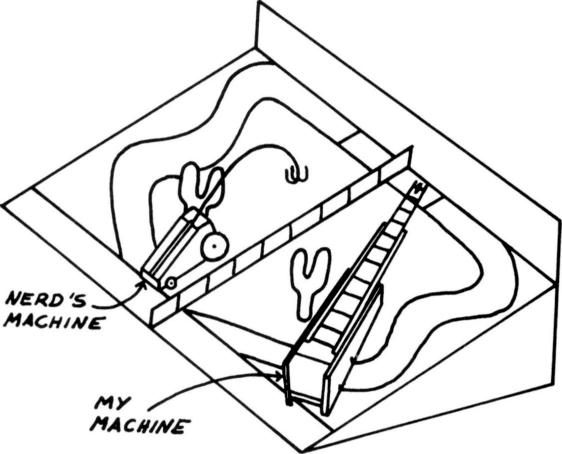

“萨沃克！” 我的弹簧打火石轮消防梯在十分之一秒内就在秤上产生了 1 盎司的偏转。抓钩飞向一边，没有击中篮板，GH 先生的卡车已经沉入水中。

"Thawockkk!" My spring- loaded-Flintstone-wheel- fireengine-ladder put a 1-ounce deflection on the scale in a tenth of a second. The grappling hook shot off to the side, missed the backboard, and Mr. G.H.'s truck was dead in the water.

我看着威尔逊教授。威尔逊教授看着我。

I looked at Professor Wilson. Professor Wilson looked at me.

“那太棒了，佩珀。”

"That was great, Pepper."

# 章节

# C H A P T E R

# 13

# 13

# 自杀无痛苦吗？

# Is Suicide Painless?

11 月 21 日

November 21

比赛结束后，我帮助格里菲斯、布莱和威尔逊以 26-100 获胜，并于 11:00 回到我的导师公寓。男孩，我很高兴一切都结束了，我想。现在我可以稍微休息一下，也许直到圣诞节。啊，现在我可以睡觉了。是的，接下来的四个星期可以睡个好觉。

I helped Griffith and Bligh and Wilson lift the pieces of the contest out of 26-100 after it was over and went back to my tutor apartment at 11:00. Boy, am I glad that's over, I thought. Now I can coast for a bit, maybe until Christmas. Ah, now I can sleep. Yes, a nice restful sleep for the next four weeks.

我走过三楼平台上的大富翁游戏，他们说：“很棒的梯子，Pepper。太棒了。”

I walked past the Monopoly game on the third floor landing and they said, "Great ladder, Pepper. Wicked awesome."

哎呀，没什么。

Aw shucks, it was nothing.

Campagnolo 自行车零部件的工程总监就在观众席上。他是威尔逊的朋友，”黛安娜说。“也许你可以帮他找一份工作。”

The engineering director of Campagnolo cycling components was in the audience. He's a buddy of Wilson," Dianne said. "Maybe you can hit him up for a job."

“是的，那就太好了。也许我会尝试一下。”

"Yeah, that'd be great. Maybe I'll try that."

克维尔，克维尔，克维尔。

Kvel, kvel, kvel.

我祝贺辛迪的表现；她的抓钩进入了半决赛。

I congratulated Cindy on her performance; her grappling hook made it to the semifinals.

“哦，顺便说一句，”她说，“约翰·多尔西在你的门下留了一张纸条。他说这很重要。”

"Oh, by the way," she said, "John Dorsey left a note under your door. He said it was important."

它总是有一些东西，不是吗？如果这不是一回事那就是另一回事了。就像 Gilda Radner 的祖母 Nanna Rosanne Rosanna Danna 经常说的那样。

It's always something, isn't it. If it's not one thing it's another thing. Just like Gilda Radner's grandmother Nanna Rosanne Rosanna Danna always used to say.

“请见我。如果您在 11:30 之前到达，请来我的公寓。”

"Please see me. Come by my apartment if you're in by 11:30."

不好了。也许他们想让我离开，我将不得不重新开始购买杂货并支付租金。我走到多尔西一家位于克拉夫茨的公寓。

Oh, no. Maybe they want me out and I'll have to start buying groceries and paying rent again. I walked over to the Dorseys' apartment in Crafts.

“嗨，约翰。有什么事吗？”

"Hi, John. What's up?"

“我是史蒂夫·沃森，”约翰说。“他有严重的情绪问题。他抑郁、孤独，已经开始担心期末考试了。精神科医生办公室和一位宗教顾问都和他谈过，他们认为他已经快要好转了。他几乎在三年内完成了本科学业。”已经半年了，他还不到十九岁。我想他正在意识到自己没有生活。”

"It's Steve Watson," John said. "He's having serious emotional troubles. He's depressed and lonely and already worried about finals. The psychiatrist's office and one of the religious counselors have both talked to him, and they think he's close to rounding the bend. He's almost finished his undergraduate work in three and a half years and he's not even nineteen yet. I think he's in the process of realizing he doesn't have a life."

十九岁时，他出生在古巴导弹危机和肯尼迪遇刺之间的某个时间。

At nineteen, he was born some time between the Cuban missile crisis and Kennedy's assassination.

“哎呀，太可怕了，”我说。“史蒂夫·沃森是谁？”

"Gee, that's terrible," I said. "Who's Steve Watson?"

“他是你报名的学生之一。你还没有认识他们每一个人吗？这是你导师工作的一部分，你知道。无论如何，我们希望你留意他，也许可以招募一些他大厅入口处的学生也要做同样的事情，让他们对他友好，你对他友好，试着让他觉得他过去的三年半并不是完全的情感真空。”

"He's one of the students on your entry. Haven't you gotten to know every one of them? That's part of your tutor job, you know. Anyway, we'd like you to keep an eye on him, maybe recruit some of the students in the entry on his hall to do the same, have them be friendly to him, you be friendly to him, try to make him feel that his last three and a half years were not a total emotional vacuum."

“我会尽我所能，约翰。嘿，我已经尽了最大努力去了解每个人。好吧，也许不是通过名字，但无论如何，通过面孔。我的意思是，在每次学习休息之前，我都会张贴标志然后去敲每一扇门。如果这个孩子总是在他的实验室里，我能帮忙吗？

"I'll do what I can, John. And hey, I've done my best to get to know everyone. Well, maybe not by name, but by face anyway. I mean before every study break, I put the signs up and then go and knock on every door. Can I help it if this kid is always at his lab?"

“不，你不能，而且我相信你已经尽力了。最主要的事情是照顾史蒂夫。我在这里当舍监已经三年了，还没有发生过自杀事件。” ，如果我能帮忙的话，只要我在这里，就不会有任何帮助。”

"No, you can't, and I'm sure you're doing your best. The main thing to do is to take care of Steve. I've been housemaster here for three years and there hasn't been a suicide yet, and if I can help it there won't be any for as long as I'm here."

“对我来说也是如此，约翰。你对我应该如何与他交谈有什么建议吗？”

"Ditto for me, John. Do you have any suggestions for how I should talk to him?"

“尽量表现得自然一点，别让人觉得你在关注他。试着对他感兴趣的事情感兴趣。我听说他喜欢下棋，也许你可以和他下棋或者鼓励其他学生也这样做。”

"Just try to be natural; don't let on that you're keeping an eye on him. Try taking an interest in things that are interesting to him. I heard he likes to play chess. Maybe you can have a game with him or encourage the other students to do the same."

我想，我这个拿薪水的员工，还得拿钱才能对这个孩子好，这真是太糟糕了。其他人没有时间或意愿。每所学校都有孤独者，但麻省理工学院对他们有着巨大的吸引力。当你把八个孤独的人放在宿舍地板上时，你会得到什么？八个非常孤独的人。

It's really too bad that I, a paid staffer, have to be paid to be nice to this kid, I thought. Nobody else has the time or the inclination. There are loners at every school but MIT is a magnet for them. And what do you get when you put eight loners on a dormitory floor? Eight very lonely people.

12月11日

December 11

在度过了一个宁静的感恩节之后，在假期后的一个半星期里多次尝试找到他之后，我遇到了史蒂夫。他的门上有一个记事板，上面写着：“我应该自杀吗？” 在它的下面有一个“是”栏和一个“否”栏。“否”下有七个井号标记，“是”下有两个井号标记。有人在其中一个“是”标记的一侧写下了“跳，跳”。底部是别人的手写的，“生活是个婊子，然后你就死了。” 知道人们关心他，史蒂夫一定很高兴。

After a restful Thanksgiving, and after several attempts at finding him during the week and a half following the vacation, I met Steve. There was a noteboard on his door that said, "Should I kill myself?" and beneath it there was a Yes column and a No column. There were seven hash marks under No and two under Yes. Somebody'd written, "Jump, jump" to the side of one of the Yes marks. On the bottom someone else's hand had written, "Life's a bitch, and then you die." It must have made Steve happy to know that people cared.

史蒂夫皮肤苍白，痤疮逐渐消退，下巴上有一点棕色的胡须，还有小胡子。他身材苗条、高大、安静。他当然很安静。这就是为什么他不认识任何人。

Steve had pale skin, a receding case of acne, a little brown beard on his chin, and a mustache. He was slim, tall, and quiet. Of course he was quiet; that's why he didn't know anyone.

“嗨，”当他打开门时我说。“我是 Pepper White，导师。我还没有机会见到每个人，但我正在努力确保我见到每个人，并让大家知道考试周期间每天晚上都会有一个学习休息时间……如果你想过来聊天，请随时敲我的门。”

"Hi," I said when he opened the door. "I'm Pepper White, the tutor. I haven't had a chance to meet everyone yet, but I'm trying to make sure I meet everyone and let you all know that there will be a study break every night during exam week. And if you ever want to come by and chat, feel free to knock on my door."

“他们让你这么做的，不是吗？” 他说。

"They put you up to this, didn't they?" he said.

“做什么？你说，那儿有国际象棋吗？我也喜欢下棋。也许我们什么时候可以比赛一下。”

"Up to what? Say, is that a chess set there? I like to play chess, too. Maybe we can have a match sometime."

抑郁症一定削弱了他的抵抗力，削弱了他从环境中吸收的愤世嫉俗。“当然，那太好了，”他说。他露出笑容，显然很感谢任何人提供的友谊。

The depression must have weakened his resistance, the cynicism that he'd absorbed from the environment. "Sure, that would be nice," he said. He cracked a smile, apparently thankful for any offer of friendship.

“明天下午1点30分怎么样？” 我问。

"How about tomorrow at 1:30 in the afternoon?" I asked.

“好的。”

"OK."

黛安开始用一个真正的保龄球和空的两升姜汁汽水瓶作为瓶瓶打保龄球。咚！球击中了史蒂夫家旁边的厚重橡木门。十个别针中的三个落了下来。

Dianne started bowling with a real bowling ball and empty two-liter ginger ale bottles as the pins. Thunk! The ball hit the heavy oak door next to Steve's. Three of the ten pins went down.

“嘿，你能把它放在那里吗？” 我说。

"Hey, can you keep it down there?" I said.

黛安娜反驳道：“如果我不练习的话，我怎么能在这方面做得更好呢？”

Dianne retorted, "How am I going to get any better at this if I don't practice?"

“黛安，你认识史蒂夫吗？他主修数学和物理。你上过一些物理课，不是吗？”

"Say, Dianne, do you know Steve? He's a math and physics major. You've taken some physics classes, haven't you?"

“哦，是的，当然，好吧，”黛安说，很快就明白了我的暗示。“你不是在我的相对论课上吗，史蒂夫？那个法国教授，他真的很会讲课，不是吗？我在黑洞史瓦西半径的材料上遇到了一点麻烦。你能帮我概念化它吗？” ？”

"Oh, yeah, sure, OK," Dianne said, quickly figuring out what I was hinting. "Aren't you in my relativity class, Steve? That Professor French, he can really lecture, can't he? I'm having a little trouble with the material on the Schwarzschild radius for black holes. Could you help me conceptualize it?"

“这是一个非常简单的概念，”史蒂夫说，他的信心因有机会向某人解释而增强。“数学有点复杂——我的意思是，它是微分方程的奇点解——但这个想法是，当你接近黑洞，并且在时空连续体中距离它一定距离时，就会有无路可退。”

"It's a pretty easy concept," Steve said, his confidence growing at the chance to explain something to someone. "The mathematics is a little hairy-I mean, it's a singular point solution for a differential equation-but the idea is that as you approach a black hole, and you come within a certain distance of it in the space-time continuum, there's no turning back."

“你的意思是你有点陷入其中，就像在科幻电影中一样？” 黛安娜问道。

"You mean you sort of get sucked into it, like in a sci-fi movie?" Dianne asked.

“是的，就是这样，”史蒂夫说。“你了解双胞胎的问题吗？其中一个离开地球，以接近光速旅行，六十年后才回来，而他的哥哥已经六十岁了，而他却没有？”

"Yeah, that's it," Steve said. "Did you understand the problem about the twins, one of whom leaves earth and travels at close to the speed of light and he comes back sixty years later, and his brother has aged sixty years but he hasn't?"

“当然，”黛安娜说，“这就是狭义相对论，我想我已经掌握了它。”

"Sure," Dianne said, "that's special relativity, and I think I've got a handle on that."

黛安开始解释这个问题，我想她暂时已经替史蒂夫解决了，所以我原谅自己说：“明天 1 点 30 分那场国际象棋比赛见，好吗，史蒂夫？”

Dianne started to explain the problem, and I figured she had Steve covered for the time being so I excused myself and said, "I'll see you at 1:30 tomorrow for that chess game, OK, Steve?"

12月12日

December 12

星期日。下午1点30分，史蒂夫还在睡觉。当你抑郁的时候，你只想睡觉，而当你在麻省理工学院时，你几乎没有时间睡觉，因此你只想睡觉，你的身体感觉和你在麻省理工学院时一样。抑郁，很难判断你是抑郁还是只是因为工作而感到疲倦。我反复敲门，然后在外面等着。来吧，史蒂夫，去开门。

Sunday. Steve was still asleep at 1:30 in the afternoon. When you're depressed, all you want to do is sleep, and when you're at MIT, you have very little time to sleep, and therefore all you want to do is sleep and your body feels the same as when you're depressed and it's hard to tell whether you're depressed or just tired from all the work. I knocked repeatedly and waited outside. Come on, Steve, answer the door.

大约五分钟后，他终于回答了。他睡眼惺忪地说：“哦，是的，我忘记了我们的国际象棋比赛。我们可以改天再做吗？我将在 2:00 在朗克尔对弈一个人。不过还是谢谢你叫醒我。否则我可能会错过比赛。”

He finally answered after about five minutes. He was groggyeyed, and said, "Oh, yeah, I forgot about our chess game. Can we do it some other time? I'm going to play a guy in Runkle at 2:00. Thanks for waking me up, though. I might have missed my match otherwise."